# Global Human Rights Disparities Analysis

Ashley Yu

## Relevant libaries import:

```python
import matplotlib.pyplot as plt
import pandas as pd
import numpy as np
import random
import sympy as sp
from pivottablejs import pivot_ui
import hvplot.pandas
from bokeh.io import output_notebook
import seaborn as sns
```

**Insight Question 1**:

Between high-income countries and low/middle income countries, do people have different overall right to safety from state from 2017-2023? Specifically, do people’s Physical Integrity Rights postively correlated with migrants/immigrants' risk of torture and ill-treatment?

Part 1: People in High-Income Countries have more Physical Integrity Rights

1. Import the dataset:  
`hiy` is Income-Adjusted Data Sets of High Income Countries  
`identity` is HRMI People at Risk (PaR) Dataset  
`cpr` is HRMI Civil and Political Rights (CPR) Dataset

```python
hiy = pd.read_csv('csv files/esr_hiy_incomeadjusted.csv')
identity = pd.read_csv('csv files/people_at_risk.csv')
cpr = pd.read_csv('csv files/cpr.csv')
```

2. Data processing  
In the dataset `hiy`, the column High_Income_Country uses numeric labels:

- 1 represents High-Income Countries (HIY).
- 0 represents Low- and Middle-Income Countries (LMY).

3. Label the data

A new dataset `hiy_label` is created with 'Country' and 'High_Income_Country'.

```python
hiy['High_Income_Country'] = hiy['High_Income_Country'].replace({1: 'HIY', 0: 'LMY'})
hiy = hiy.drop_duplicates(subset=['Country'])
hiy_label = hiy[['Country','High_Income_Country']]
display(hiy_label)
```

|  | Country | High_Income_Country |
| --- | --- | --- |
| 0 | Aruba | HIY |
| 32 | Afghanistan | LMY |
| 64 | Angola | LMY |
| 96 | Albania | LMY |
| 128 | Andorra | HIY |
| ... | ... | ... |
| 6944 | Kosovo | LMY |
| 6976 | Yemen, Rep. | LMY |
| 7008 | South Africa | LMY |
| 7040 | Zambia | LMY |
| 7072 | Zimbabwe | LMY |

222 rows × 2 columns

4. Merge the data:

Merge the income classification labels `hiy_label` with the Civil and Political Rights dataset `cpr`, adding the income group (HIY / LMY) for each country. Extract variables related to Physical Integrity Rights (Physint).

- **Physint**: Physical Integrity Rights, which measure people's overall right to safety from the state.

```python
cpr = cpr.copy()
hiy_label = hiy_label.copy()
cpr.rename(columns={'country': 'Country'}, inplace=True)
hiy_label.rename(columns={'High_Income_Country': 'Label'}, inplace=True)
label_merge = pd.merge(cpr, hiy_label, on='Country', how='inner')
display(label_merge)
cpr_phy = label_merge[['Country', 'year', 'physint_mean', 'physint_sd', 'physint_lo', 'physint_hi', 'Label']]
display(cpr_phy)
```

|  | Country | year | countryyear | iso3c | iso3n | cowcode | hrmicode | disap_mean | disap_sd | disap_lo | ... | rel_hi | physint_mean | physint_sd | physint_lo | physint_hi | empower_mean | empower_sd | empower_lo | empower_hi | Label |
| --- | --- | --- | --- | --- | --- | --- | --- | --- | --- | --- | --- | --- | --- | --- | --- | --- | --- | --- | --- | --- | --- |
| 0 | Angola | 2017 | AGO2017 | AGO | 24.0 | 540.0 | 1 | 6.464161 | 0.898106 | 5.314585 | ... | NaN | 4.401868 | 0.795705 | 3.383366 | 5.420371 | 2.735583 | 0.737381 | 1.791735 | 3.679431 | LMY |
| 1 | Angola | 2018 | AGO2018 | AGO | 24.0 | 540.0 | 1 | 7.174069 | 0.491192 | 6.545342 | ... | NaN | 5.122885 | 0.812793 | 4.082510 | 6.163259 | 4.580472 | 0.701104 | 3.683059 | 5.477886 | LMY |
| 2 | Angola | 2019 | AGO2019 | AGO | 24.0 | 540.0 | 1 | 6.357960 | 0.626105 | 5.556545 | ... | NaN | 4.486554 | 0.790036 | 3.475308 | 5.497800 | 4.226362 | 0.671121 | 3.367327 | 5.085398 | LMY |
| 3 | Angola | 2020 | AGO2020 | AGO | 24.0 | 540.0 | 1 | 5.453531 | 0.792786 | 4.438765 | ... | NaN | 3.438196 | 0.924271 | 2.255129 | 4.621263 | 2.709881 | 0.691141 | 1.825221 | 3.594541 | LMY |
| 4 | Angola | 2021 | AGO2021 | AGO | 24.0 | 540.0 | 1 | 4.963902 | 0.588297 | 4.210882 | ... | NaN | 3.121782 | 0.849364 | 2.034596 | 4.208967 | 2.996323 | 0.736295 | 2.053865 | 3.938781 | LMY |
| ... | ... | ... | ... | ... | ... | ... | ... | ... | ... | ... | ... | ... | ... | ... | ... | ... | ... | ... | ... | ... | ... |
| 177 | Thailand | 2023 | THA2023 | THA | 764.0 | 800.0 | 47 | 8.162083 | 0.621875 | 7.366082 | ... | 9.428472 | 6.726162 | 0.901969 | 5.571642 | 7.880681 | 4.842543 | 0.708837 | 3.935232 | 5.749854 | LMY |
| 178 | Singapore | 2022 | SGP2022 | SGP | 702.0 | 830.0 | 49 | 8.410766 | 0.316615 | 8.005499 | ... | 7.127632 | 7.231867 | 0.765176 | 6.252442 | 8.211292 | 4.089519 | 0.672613 | 3.228574 | 4.950464 | HIY |
| 179 | Singapore | 2023 | SGP2023 | SGP | 702.0 | 830.0 | 49 | 8.403709 | 0.313198 | 8.002816 | ... | 7.073044 | 7.294268 | 0.743383 | 6.342738 | 8.245797 | 4.190406 | 0.712885 | 3.277913 | 5.102899 | HIY |
| 180 | Sri Lanka | 2022 | LKA2022 | LKA | 144.0 | 780.0 | 50 | 7.047200 | 0.292876 | 6.672319 | ... | 6.533591 | 5.090563 | 0.740136 | 4.143188 | 6.037937 | 3.610210 | 0.680381 | 2.739323 | 4.481098 | LMY |
| 181 | Sri Lanka | 2023 | LKA2023 | LKA | 144.0 | 780.0 | 50 | 7.356123 | 0.282373 | 6.994685 | ... | 6.520242 | 5.441030 | 0.729936 | 4.506712 | 6.375348 | 3.370074 | 0.657596 | 2.528351 | 4.211797 | LMY |

182 rows × 52 columns

|  | Country | year | physint_mean | physint_sd | physint_lo | physint_hi | Label |
| --- | --- | --- | --- | --- | --- | --- | --- |
| 0 | Angola | 2017 | 4.401868 | 0.795705 | 3.383366 | 5.420371 | LMY |
| 1 | Angola | 2018 | 5.122885 | 0.812793 | 4.082510 | 6.163259 | LMY |
| 2 | Angola | 2019 | 4.486554 | 0.790036 | 3.475308 | 5.497800 | LMY |
| 3 | Angola | 2020 | 3.438196 | 0.924271 | 2.255129 | 4.621263 | LMY |
| 4 | Angola | 2021 | 3.121782 | 0.849364 | 2.034596 | 4.208967 | LMY |
| ... | ... | ... | ... | ... | ... | ... | ... |
| 177 | Thailand | 2023 | 6.726162 | 0.901969 | 5.571642 | 7.880681 | LMY |
| 178 | Singapore | 2022 | 7.231867 | 0.765176 | 6.252442 | 8.211292 | HIY |
| 179 | Singapore | 2023 | 7.294268 | 0.743383 | 6.342738 | 8.245797 | HIY |
| 180 | Sri Lanka | 2022 | 5.090563 | 0.740136 | 4.143188 | 6.037937 | LMY |
| 181 | Sri Lanka | 2023 | 5.441030 | 0.729936 | 4.506712 | 6.375348 | LMY |

182 rows × 7 columns

5. Visualize the data

Create a line graph that shows the average Physical Integrity Rights (`physint_mean`) for high-income (HIY) and low/middle-income (LMY) countries over the years 2017–2023.

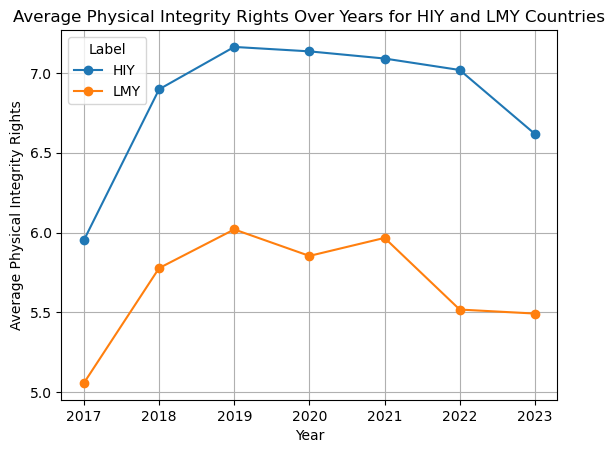

```python
averaged_data = cpr_phy.groupby(['Label', 'year'])['physint_mean'].mean().reset_index()
hiy_data = averaged_data[averaged_data['Label'] == 'HIY']
lmy_data = averaged_data[averaged_data['Label'] == 'LMY']
plt.plot(hiy_data['year'], hiy_data['physint_mean'], label='HIY', marker='o')
plt.plot(lmy_data['year'], lmy_data['physint_mean'], label='LMY', marker='o')
plt.xlabel('Year')
plt.ylabel('Average Physical Integrity Rights')
plt.title('Average Physical Integrity Rights Over Years for HIY and LMY Countries')
plt.legend(title='Label')
plt.grid(True)
plt.show()
```

6. Observation

From the line graph, high-income countries (HIY) shows higher averaged physical integrity right than low/middle-income (LMY) countries across all different years. Thus, people in high-income countries overall have more right to safety from the state.

Part 2: In both HIY and LMY, migrant/immigrant risk of torture and ill-treatment show great variations.

1. Merge Data

Merge the HRMI People at Risk dataset `identity` with the income classification labels `hiy_label`, adding a classification of High-Income (HIY) or Low/Middle-Income (LMY) for each country.

2. Extract Migrant/Immigrant related Data

Extract variables related to migrants and immigrants `identity_imm`.

- `tort_atrisk_prop24`: Proportion of respondents who identified migrants/immigrants at risk of torture and ill-treatment.
- `tort_atrisk_count24`: Count of respondents identifying migrants/immigrants at risk of torture and ill-treatment.

```python
hiy_label = hiy_label.copy()
hiy_label.rename(columns={'High_Income_Country': 'Label'}, inplace=True)
identity.rename(columns={'country': 'Country'}, inplace=True)
label_identity = pd.merge(identity, hiy_label, on='Country', how='inner')
display(label_identity)
identity_imm = label_identity[['Country', 'year', 'tort_atrisk_prop24', 'tort_atrisk_count24', 'Label']]
display(identity_imm)
```

|  | Country | year | countryyear | iso3c | iso3n | cowcode | hrmicode | food_total_atrisk_resp | food_atrisk_count1 | food_atrisk_prop1 | ... | union_atrisk_prop27 | union_atrisk_count28 | union_atrisk_prop28 | union_atrisk_count29 | union_atrisk_prop29 | union_atrisk_count30 | union_atrisk_prop30 | union_atrisk_count31 | union_atrisk_prop31 | Label |
| --- | --- | --- | --- | --- | --- | --- | --- | --- | --- | --- | --- | --- | --- | --- | --- | --- | --- | --- | --- | --- | --- |
| 0 | Angola | 2018 | AGO2018 | AGO | 24.0 | 540.0 | 1 | 11 | 3 | 0.272727 | ... | 0.090909 | 2.0 | 0.181818 | 3.0 | 0.272727 | 4.0 | 0.363636 | 1.0 | 0.090909 | LMY |
| 1 | Angola | 2019 | AGO2019 | AGO | 24.0 | 540.0 | 1 | 14 | 3 | 0.214286 | ... | NaN | NaN | NaN | NaN | NaN | NaN | NaN | NaN | NaN | LMY |
| 2 | Angola | 2020 | AGO2020 | AGO | 24.0 | 540.0 | 1 | 13 | 3 | 0.230769 | ... | NaN | NaN | NaN | NaN | NaN | NaN | NaN | NaN | NaN | LMY |
| 3 | Angola | 2021 | AGO2021 | AGO | 24.0 | 540.0 | 1 | 12 | 6 | 0.500000 | ... | NaN | NaN | NaN | NaN | NaN | NaN | NaN | NaN | NaN | LMY |
| 4 | Angola | 2022 | AGO2022 | AGO | 24.0 | 540.0 | 1 | 10 | 5 | 0.500000 | ... | NaN | NaN | NaN | NaN | NaN | NaN | NaN | NaN | NaN | LMY |
| ... | ... | ... | ... | ... | ... | ... | ... | ... | ... | ... | ... | ... | ... | ... | ... | ... | ... | ... | ... | ... | ... |
| 139 | Maldives | 2023 | MDV2023 | MDV | 462.0 | 781.0 | 46 | 7 | 0 | 0.000000 | ... | NaN | NaN | NaN | NaN | NaN | NaN | NaN | NaN | NaN | LMY |
| 140 | Thailand | 2022 | THA2022 | THA | 764.0 | 800.0 | 47 | 13 | 4 | 0.307692 | ... | NaN | NaN | NaN | NaN | NaN | NaN | NaN | NaN | NaN | LMY |
| 141 | Thailand | 2023 | THA2023 | THA | 764.0 | 800.0 | 47 | 6 | 0 | 0.000000 | ... | NaN | NaN | NaN | NaN | NaN | NaN | NaN | NaN | NaN | LMY |
| 142 | Singapore | 2023 | SGP2023 | SGP | 702.0 | 830.0 | 49 | 7 | 1 | 0.142857 | ... | NaN | NaN | NaN | NaN | NaN | NaN | NaN | NaN | NaN | HIY |
| 143 | Sri Lanka | 2023 | LKA2023 | LKA | 144.0 | 780.0 | 50 | 29 | 12 | 0.413793 | ... | NaN | NaN | NaN | NaN | NaN | NaN | NaN | NaN | NaN | LMY |

144 rows × 1359 columns

|  | Country | year | tort_atrisk_prop24 | tort_atrisk_count24 | Label |
| --- | --- | --- | --- | --- | --- |
| 0 | Angola | 2018 | 0.615385 | 8.0 | LMY |
| 1 | Angola | 2019 | 0.562500 | 9.0 | LMY |
| 2 | Angola | 2020 | 0.071429 | 1.0 | LMY |
| 3 | Angola | 2021 | 0.333333 | 4.0 | LMY |
| 4 | Angola | 2022 | 0.090909 | 1.0 | LMY |
| ... | ... | ... | ... | ... | ... |
| 139 | Maldives | 2023 | 0.857143 | 6.0 | LMY |
| 140 | Thailand | 2022 | 0.071429 | 1.0 | LMY |
| 141 | Thailand | 2023 | 0.333333 | 2.0 | LMY |
| 142 | Singapore | 2023 | 0.142857 | 1.0 | HIY |
| 143 | Sri Lanka | 2023 | 0.068966 | 2.0 | LMY |

144 rows × 5 columns

3. Visualize the data

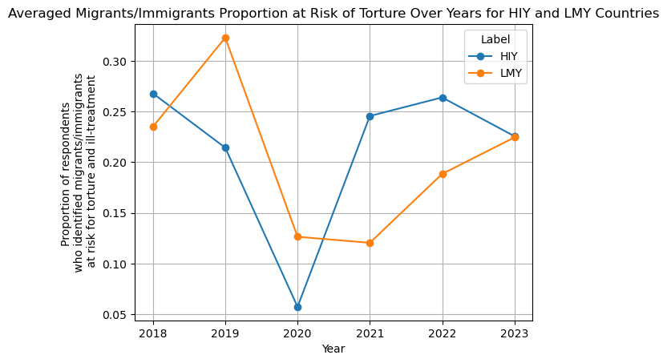

```python
averaged_imm = identity_imm.groupby(['Label', 'year'])['tort_atrisk_prop24'].mean().reset_index()
hiy_imm = averaged_imm[averaged_imm['Label'] == 'HIY']
lmy_imm = averaged_imm[averaged_imm['Label'] == 'LMY']
plt.plot(hiy_imm['year'], hiy_imm['tort_atrisk_prop24'], label='HIY', marker='o')
plt.plot(lmy_imm['year'], lmy_imm['tort_atrisk_prop24'], label='LMY', marker='o')
plt.xlabel('Year')
plt.ylabel('Proportion of respondents \n who identified migrants/immigrants \n at risk for torture and ill-treatment')
plt.title('Averaged Migrants/Immigrants Proportion at Risk of Torture Over Years for HIY and LMY Countries')
plt.legend(title='Label')
plt.grid(True)
plt.show()
```

4. Calculate standard deviation

Calculate the standard deviation (std) of the proportion of respondents `tort_atrisk_prop24` identifying migrants/immigrants as at risk of torture and ill-treatment for each income group (Label - HIY and LMY)to measure how much the values vary or spread out from the mean within each income group.

```python
print(identity_imm.groupby('Label')['tort_atrisk_prop24'].std())
```

```
Label
HIY    0.215330
LMY    0.219511
Name: tort_atrisk_prop24, dtype: float64
```

5. Observation

The line plot shows that, between high-income (HIY) and low/middle-income (LMY) countries, there is no significant difference in the average proportion of migrants/immigrants at risk of torture and ill-treatment. This insignificant result may largely due to high variability and the influence of outliers within both groups:

- Both HIY and LMY groups show a standard deviation of approximately 0.2, which is substantial given the range of values (0.05 to 0.3). This large variability in responses within each group makes it difficult to detect meaningful differences between the two income groups.
- High standard deviation suggests the existence of outliers in both groups.

Outliers could disproportionately influence the overall averages.

Part 3: People in HIY have more physical integrity rights, and migrants/immigrants experience lower risks of torture and ill-treatment

1. Merge the data

Merge `cpr_phy` (Physical Integrity Rights data) with `identity_imm` (migrants/immigrants' risks). The new dataset after combination is called `final_merge`.

```python
final_merge = pd.merge(cpr_phy, identity_imm, on='Country', how='inner')
display(final_merge)
```

|  | Country | year_x | physint_mean | physint_sd | physint_lo | physint_hi | Label_x | year_y | tort_atrisk_prop24 | tort_atrisk_count24 | Label_y |
| --- | --- | --- | --- | --- | --- | --- | --- | --- | --- | --- | --- |
| 0 | Angola | 2017 | 4.401868 | 0.795705 | 3.383366 | 5.420371 | LMY | 2018 | 0.615385 | 8.0 | LMY |
| 1 | Angola | 2017 | 4.401868 | 0.795705 | 3.383366 | 5.420371 | LMY | 2019 | 0.562500 | 9.0 | LMY |
| 2 | Angola | 2017 | 4.401868 | 0.795705 | 3.383366 | 5.420371 | LMY | 2020 | 0.071429 | 1.0 | LMY |
| 3 | Angola | 2017 | 4.401868 | 0.795705 | 3.383366 | 5.420371 | LMY | 2021 | 0.333333 | 4.0 | LMY |
| 4 | Angola | 2017 | 4.401868 | 0.795705 | 3.383366 | 5.420371 | LMY | 2022 | 0.090909 | 1.0 | LMY |
| ... | ... | ... | ... | ... | ... | ... | ... | ... | ... | ... | ... |
| 815 | Thailand | 2023 | 6.726162 | 0.901969 | 5.571642 | 7.880681 | LMY | 2023 | 0.333333 | 2.0 | LMY |
| 816 | Singapore | 2022 | 7.231867 | 0.765176 | 6.252442 | 8.211292 | HIY | 2023 | 0.142857 | 1.0 | HIY |
| 817 | Singapore | 2023 | 7.294268 | 0.743383 | 6.342738 | 8.245797 | HIY | 2023 | 0.142857 | 1.0 | HIY |
| 818 | Sri Lanka | 2022 | 5.090563 | 0.740136 | 4.143188 | 6.037937 | LMY | 2023 | 0.068966 | 2.0 | LMY |
| 819 | Sri Lanka | 2023 | 5.441030 | 0.729936 | 4.506712 | 6.375348 | LMY | 2023 | 0.068966 | 2.0 | LMY |

820 rows × 11 columns

2. Visualize the data

Create an interactive scatter plot showing the relationship between: `physint_mean` (Physical Integrity Rights) and `tort_atrisk_prop24` (Proportion of migrants/immigrants at risk of torture and ill-treatment), comparing high-income (HIY) and low/middle-income (LMY) countries.

- X-axis: Average Physical Integrity Rights (`physint_mean`).
- Y-axis: Proportion of migrants/immigrants at risk of torture (`tort_atrisk_prop24`).
- Blue dots represent HIY countries
- Red dots represent LMY countries.

```python
scatter_data = final_merge.groupby(['Country', 'Label_x']).agg({
    'physint_mean': 'mean',
    'tort_atrisk_prop24': 'mean'
}).reset_index()

hiy_data = scatter_data[scatter_data['Label_x'] == 'HIY']
lmy_data = scatter_data[scatter_data['Label_x'] == 'LMY']

hiy_scatter = hiy_data.hvplot.scatter(
    x='physint_mean',
    y='tort_atrisk_prop24',
    by='Country',
    marker='o',
    color='blue',
    label='HIY',
    xlabel='Average Physical Integrity Rights',
    ylabel='Average Proportion of respondents \n who identified migrants/immigrants \n at risk for torture and ill-treatment'
)

lmy_scatter = lmy_data.hvplot.scatter(
    x='physint_mean',
    y='tort_atrisk_prop24',
    by='Country',
    marker='o',
    color='red',
    label='LMY',
    xlabel='Average Physical Integrity Rights',
    ylabel='Average Proportion of respondents \n who identified migrants/immigrants \n at risk for torture and ill-treatment'
)

final_plot = (hiy_scatter * lmy_scatter).opts(
    title='Interactive Scatter Plot: \n Physical Integrity Rights vs. \n Migrant/Immigrant Risks Between HIY and LMY',
    legend_position='right',
    width=800,
    height=600
)

final_plot
```

[output not shown]

3. Observation

In the line graph comparing high-income (HIY) and low/middle-income (LMY) countries, there appears to be no significant distinction in the averaged proportion of migrants/immigrants at risk of torture and ill-treatment. This lack of clear distinction could be attributed to the significant variance within each income group. By averaging the countries in just two broad groups (HIY and LMY), we may overlook the heterogeneity and outliers within these groups.

In contrast, the scatter plot above zooms in the data for individual countries within each group, allowing us to reduce the influence of the large variation in the averages and provide a more precise evaluation. By plotting each country individually, between high-income and low/middle-income countries, there is a clear differences in the pattern of average physical integrity rights and propotion of immigrants/migrants at risk of torture and ill-treatment.

For **high income countries**: HIY countries cluster mostly in the lower-right corner of the scatter plot. In HIY countries, people have more physical integrity rights (`physint_mean`), which corresponds to a lower proportion of migrants/immigrants at risks of torture and ill-treatment (`tort_atrisk_prop24`). Thus, in HIY countries, there is a negative correlation between people's physical integrity rights and immigrants/migrants' risks of torture and ill-treatment.

For **low income countries**: LMY countries show great variability, with points scattered across the graph. This reflects wide disparities in physical integrity rights and immigrants/migrants' risks of torture and ill-treatment. Thus, in low/middle-income countries, there is no correlation between people's physical integrity rights and immigrants/migrants' risks of torture and ill-treatment.

However, two **outliers** are identified in HIY:

- The United States:

Located at approximately (4.8, 0.6), it exhibits a lower-than-expected physical integrity score and higher risks for migrants/immigrants compared to other HIY countries.

- Saudi Arabia:

Found at (3.1, 0.3), it has a low physical integrity score and a moderate risk proportion, deviating from the general HIY trend.

**Insight 1** :

From 2017 to 2023, people in high-income countries (HIY) overall have more rights to safety from state compared to people in low/middle income countries. A stronger protection for physical integrity rights in high-income countries also correlates to lower proportions of migrants/immigrants at risks of torture and ill-treatment, indicating a negative correlation. Thus, in high-income countries, stronger overall protections for physical integrity is related with better safety and rights for migrants/immigrants. In contrast, in low/middle-income countries, there is a considerable variability in both physical integrity rights and the risks faced by migrants/immigrants. Thus, individuals in low/middle-income countries are lack of consistent protection, and migrants are exposed to varying degrees of risk for torture and ill-treatment. This variability reflects governance challenges and the unequal provision of physical integrity rights, leading to inconsistent safety for migrants/immigrants in low/middle-income countries.

**Insight Question 2**:

From 2017 to 2023, which human right is the most often denied or poorly protected in pacific countries vs. continental countries?

1. Import the dataset

`pacific_taiwan_data_df` is Data Sources used for Taiwan and Pacific Countries  
`cpr_df` is HRMI Civil and Political Rights (CPR) Dataset

```python
cpr_df = pd.read_csv('csv files/cpr.csv')
pacific_taiwan_data_df = pd.read_csv('csv files/Pacific_Taiwan_data.csv', encoding='latin1')
```

2. Label the data

Add a binary column 'pacific_binary' to `cpr_df`:

- 1 indicates the country is in the Pacific region.
- 0 indicates the country is not in the Pacific region.

```python
pacific_countries = pacific_taiwan_data_df['Country'].str.strip().unique()
cpr_df['pacific_binary'] = cpr_df['country'].apply(lambda x: 1 if x in pacific_countries else 0)
display(cpr_df)
```

|  | country | year | countryyear | iso3c | iso3n | cowcode | hrmicode | disap_mean | disap_sd | disap_lo | ... | rel_hi | physint_mean | physint_sd | physint_lo | physint_hi | empower_mean | empower_sd | empower_lo | empower_hi | pacific_binary |
| --- | --- | --- | --- | --- | --- | --- | --- | --- | --- | --- | --- | --- | --- | --- | --- | --- | --- | --- | --- | --- | --- |
| 0 | Angola | 2017 | AGO2017 | AGO | 24.0 | 540.0 | 1 | 6.464161 | 0.898106 | 5.314585 | ... | NaN | 4.401868 | 0.795705 | 3.383366 | 5.420371 | 2.735583 | 0.737381 | 1.791735 | 3.679431 | 0 |
| 1 | Angola | 2018 | AGO2018 | AGO | 24.0 | 540.0 | 1 | 7.174069 | 0.491192 | 6.545342 | ... | NaN | 5.122885 | 0.812793 | 4.082510 | 6.163259 | 4.580472 | 0.701104 | 3.683059 | 5.477886 | 0 |
| 2 | Angola | 2019 | AGO2019 | AGO | 24.0 | 540.0 | 1 | 6.357960 | 0.626105 | 5.556545 | ... | NaN | 4.486554 | 0.790036 | 3.475308 | 5.497800 | 4.226362 | 0.671121 | 3.367327 | 5.085398 | 0 |
| 3 | Angola | 2020 | AGO2020 | AGO | 24.0 | 540.0 | 1 | 5.453531 | 0.792786 | 4.438765 | ... | NaN | 3.438196 | 0.924271 | 2.255129 | 4.621263 | 2.709881 | 0.691141 | 1.825221 | 3.594541 | 0 |
| 4 | Angola | 2021 | AGO2021 | AGO | 24.0 | 540.0 | 1 | 4.963902 | 0.588297 | 4.210882 | ... | NaN | 3.121782 | 0.849364 | 2.034596 | 4.208967 | 2.996323 | 0.736295 | 2.053865 | 3.938781 | 0 |
| ... | ... | ... | ... | ... | ... | ... | ... | ... | ... | ... | ... | ... | ... | ... | ... | ... | ... | ... | ... | ... | ... |
| 225 | Thailand | 2023 | THA2023 | THA | 764.0 | 800.0 | 47 | 8.162083 | 0.621875 | 7.366082 | ... | 9.428472 | 6.726162 | 0.901969 | 5.571642 | 7.880681 | 4.842543 | 0.708837 | 3.935232 | 5.749854 | 0 |
| 226 | Singapore | 2022 | SGP2022 | SGP | 702.0 | 830.0 | 49 | 8.410766 | 0.316615 | 8.005499 | ... | 7.127632 | 7.231867 | 0.765176 | 6.252442 | 8.211292 | 4.089519 | 0.672613 | 3.228574 | 4.950464 | 0 |
| 227 | Singapore | 2023 | SGP2023 | SGP | 702.0 | 830.0 | 49 | 8.403709 | 0.313198 | 8.002816 | ... | 7.073044 | 7.294268 | 0.743383 | 6.342738 | 8.245797 | 4.190406 | 0.712885 | 3.277913 | 5.102899 | 0 |
| 228 | Sri Lanka | 2022 | LKA2022 | LKA | 144.0 | 780.0 | 50 | 7.047200 | 0.292876 | 6.672319 | ... | 6.533591 | 5.090563 | 0.740136 | 4.143188 | 6.037937 | 3.610210 | 0.680381 | 2.739323 | 4.481098 | 0 |
| 229 | Sri Lanka | 2023 | LKA2023 | LKA | 144.0 | 780.0 | 50 | 7.356123 | 0.282373 | 6.994685 | ... | 6.520242 | 5.441030 | 0.729936 | 4.506712 | 6.375348 | 3.370074 | 0.657596 | 2.528351 | 4.211797 | 0 |

230 rows × 52 columns

3. Select the data

Dynamically select all columns that include 'mean' in their name, which represent the average scores for different human rights.

- `Disap`: Right to freedom from disappearance
- `Exkill`: Right to freedom from extrajudicial execution
- `Arrest`: Right to freedom from arbitrary or political arrest and imprisonment
- `Tort`: Right to freedom from torture and ill-treatment
- `Depex`: Right to freedom from death penalty execution
- `Express`: Right to opinion and expression
- `Polpart`: Right to participate in government
- `Assem`: Right to assembly and association
- `Rel`: Right to freedom of religion and belief
- `Physint`: Overall right to safety from the state, i.e. Physical Integrity Rights
- `Empower`: Overall right to empowerment

```python
rights_columns = [col for col in cpr_df.columns if 'mean' in col]
display(rights_columns)
```

```
['disap_mean',
 'exkill_mean',
 'arrest_mean',
 'tort_mean',
 'dpex_mean',
 'express_mean',
 'polpart_mean',
 'assem_mean',
 'rel_mean',
 'physint_mean',
 'empower_mean']
```

4. Calculation

Calculate the average values of the selected human rights columns, grouped by `pacific_binary` and `year`.

```python
grouped_means = cpr_df.groupby(['pacific_binary', 'year'])[rights_columns].mean().reset_index()
display(grouped_means)
```

|  | pacific_binary | year | disap_mean | exkill_mean | arrest_mean | tort_mean | dpex_mean | express_mean | polpart_mean | assem_mean | rel_mean | physint_mean | empower_mean |
| --- | --- | --- | --- | --- | --- | --- | --- | --- | --- | --- | --- | --- | --- |
| 0 | 0 | 2017 | 6.733320 | 6.247352 | 5.245753 | 4.890763 | 9.230942 | 4.675750 | 4.603258 | 5.023186 | NaN | 5.368153 | 4.579556 |
| 1 | 0 | 2018 | 6.735316 | 6.199742 | 5.115282 | 4.893804 | 9.173853 | 4.625586 | 5.073367 | 5.323752 | NaN | 5.280598 | 4.812908 |
| 2 | 0 | 2019 | 6.911426 | 6.292821 | 4.920348 | 5.026125 | 9.195390 | 4.578641 | 5.143065 | 5.457412 | NaN | 5.460887 | 4.880391 |
| 3 | 0 | 2020 | 6.805790 | 6.411092 | 5.212349 | 4.964187 | 8.866773 | 4.335139 | 5.019546 | 4.740300 | NaN | 5.426631 | 4.448103 |
| 4 | 0 | 2021 | 6.749326 | 6.534168 | 5.391714 | 5.196561 | 8.971095 | 4.411066 | 5.088646 | 4.501338 | 5.103049 | 5.464674 | 4.375018 |
| 5 | 0 | 2022 | 6.827311 | 6.611590 | 5.205224 | 5.132033 | 8.844059 | 4.422194 | 5.056482 | 4.396123 | 6.558734 | 5.480520 | 4.397002 |
| 6 | 0 | 2023 | 6.892017 | 6.650289 | 5.085363 | 5.054111 | 8.794397 | 4.508944 | 4.993601 | 4.393300 | 6.528699 | 5.559597 | 4.387060 |
| 7 | 1 | 2017 | 8.292837 | 7.052309 | 5.469275 | 4.838824 | 10.000000 | 2.841465 | 4.365599 | 3.590295 | NaN | 6.566249 | 3.152234 |
| 8 | 1 | 2018 | 8.554965 | 8.021153 | 6.894804 | 6.795908 | 10.000000 | 5.856057 | 6.803963 | 7.379413 | NaN | 7.612841 | 6.698705 |
| 9 | 1 | 2019 | 8.621577 | 8.031246 | 7.357238 | 7.071760 | 10.000000 | 6.240824 | 7.021942 | 7.347842 | NaN | 7.649969 | 6.901580 |
| 10 | 1 | 2020 | 8.420540 | 8.169713 | 7.810239 | 7.158492 | 9.885901 | 6.118137 | 7.015026 | 6.891534 | NaN | 7.714486 | 6.544884 |
| 11 | 1 | 2021 | 8.492205 | 8.502044 | 8.006396 | 7.448673 | 10.000000 | 6.510010 | 7.129258 | 6.632172 | 8.946402 | 8.001933 | 6.669821 |
| 12 | 1 | 2022 | 8.402668 | 8.419019 | 7.961962 | 6.805907 | 10.000000 | 6.253374 | 6.465792 | 6.645225 | 9.271708 | 7.800919 | 6.443977 |
| 13 | 1 | 2023 | 8.377878 | 8.366530 | 7.955499 | 5.973340 | 10.000000 | 7.621193 | 6.639057 | 7.016024 | 9.297732 | 7.622438 | 7.247096 |

5. Combine the data

Reshape the data into a long format that combine all human rights into one column `right`.

Identify the human right with the lowest mean value for each combination of `pacific_binary` and `year`.

```python
lowest_means = grouped_means.melt(id_vars=['pacific_binary', 'year'], var_name='right', value_name='right_mean')
lowest_means_per_year = lowest_means.loc[lowest_means.groupby(['pacific_binary', 'year'])['right_mean'].idxmin()]
lowest_means_per_year['right'] = lowest_means_per_year['right'].replace({
    'express_mean': 'express',
    'empower_mean': 'empower',
    'assem_mean': 'assem',
    'exkill_mean': 'exkill',
    'disap_mean': 'disap',
    'arrest_mean': 'arrest',
    'tort_mean': 'tort',
    'dpex_mean': 'dpex',
    'rel_mean': 'rel',
    'physint_mean': 'physint'
})
display(lowest_means)
display(lowest_means_per_year)
```

|  | pacific_binary | year | right | right_mean |
| --- | --- | --- | --- | --- |
| 0 | 0 | 2017 | disap_mean | 6.733320 |
| 1 | 0 | 2018 | disap_mean | 6.735316 |
| 2 | 0 | 2019 | disap_mean | 6.911426 |
| 3 | 0 | 2020 | disap_mean | 6.805790 |
| 4 | 0 | 2021 | disap_mean | 6.749326 |
| ... | ... | ... | ... | ... |
| 149 | 1 | 2019 | empower_mean | 6.901580 |
| 150 | 1 | 2020 | empower_mean | 6.544884 |
| 151 | 1 | 2021 | empower_mean | 6.669821 |
| 152 | 1 | 2022 | empower_mean | 6.443977 |
| 153 | 1 | 2023 | empower_mean | 7.247096 |

154 rows × 4 columns

|  | pacific_binary | year | right | right_mean |
| --- | --- | --- | --- | --- |
| 140 | 0 | 2017 | empower | 4.579556 |
| 71 | 0 | 2018 | express | 4.625586 |
| 72 | 0 | 2019 | express | 4.578641 |
| 73 | 0 | 2020 | express | 4.335139 |
| 144 | 0 | 2021 | empower | 4.375018 |
| 103 | 0 | 2022 | assem | 4.396123 |
| 146 | 0 | 2023 | empower | 4.387060 |
| 77 | 1 | 2017 | express | 2.841465 |
| 78 | 1 | 2018 | express | 5.856057 |
| 79 | 1 | 2019 | express | 6.240824 |
| 80 | 1 | 2020 | express | 6.118137 |
| 81 | 1 | 2021 | express | 6.510010 |
| 82 | 1 | 2022 | express | 6.253374 |
| 55 | 1 | 2023 | tort | 5.973340 |

6. Split the data

Split the data for plotting into two subsets:

- `pacific_data`: Contains Pacific countries.
- `continental_data`: Contains non-Pacific (continental) countries.

```python
pacific_data = lowest_means_per_year[lowest_means_per_year['pacific_binary'] == 1]
continental_data = lowest_means_per_year[lowest_means_per_year['pacific_binary'] == 0]
display(pacific_data)
display(continental_data)
```

|  | pacific_binary | year | right | right_mean |
| --- | --- | --- | --- | --- |
| 77 | 1 | 2017 | express | 2.841465 |
| 78 | 1 | 2018 | express | 5.856057 |
| 79 | 1 | 2019 | express | 6.240824 |
| 80 | 1 | 2020 | express | 6.118137 |
| 81 | 1 | 2021 | express | 6.510010 |
| 82 | 1 | 2022 | express | 6.253374 |
| 55 | 1 | 2023 | tort | 5.973340 |

|  | pacific_binary | year | right | right_mean |
| --- | --- | --- | --- | --- |
| 140 | 0 | 2017 | empower | 4.579556 |
| 71 | 0 | 2018 | express | 4.625586 |
| 72 | 0 | 2019 | express | 4.578641 |
| 73 | 0 | 2020 | express | 4.335139 |
| 144 | 0 | 2021 | empower | 4.375018 |
| 103 | 0 | 2022 | assem | 4.396123 |
| 146 | 0 | 2023 | empower | 4.387060 |

7. Visualize the data

Create two bar plost showing how the human rights with the lowest average scores evolved over this period for Pacific and Continental countries:

- X-axis: `year`
- Y-axis: `right_mean` (the lowest mean value per year for each group).

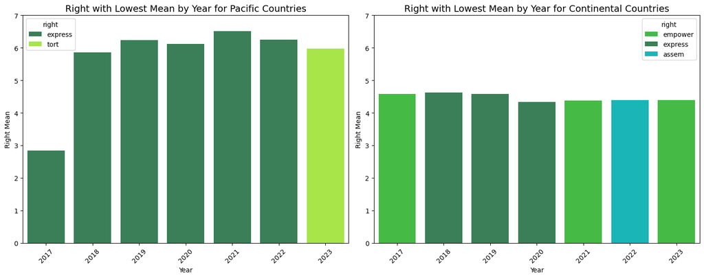

```python
# Create a figure with two subplots (1 row, 2 columns)
fig, axes = plt.subplots(1, 2, figsize=(15, 6))

custom_palette = {
    'express': 'seagreen',
    'empower': 'limegreen',
    'assem': 'darkturquoise',
    'tort': 'greenyellow'
}

# Plot for HIY countries (pacific_binary = 1) in the first subplot
sns.barplot(x='year', y='right_mean', hue='right', data=pacific_data, ax=axes[0], palette=custom_palette)
axes[0].set_title('Right with Lowest Mean by Year for Pacific Countries', fontsize=14)
axes[0].set_xlabel('Year')
axes[0].set_ylabel('Right Mean')
axes[0].tick_params(axis='x', rotation=45)
axes[0].set_ylim(0, 7)

# Plot for LMY countries (pacific_binary = 0) in the second subplot
sns.barplot(x='year', y='right_mean', hue='right', data=continental_data, ax=axes[1], palette=custom_palette)
axes[1].set_title('Right with Lowest Mean by Year for Continental Countries', fontsize=14)
axes[1].set_xlabel('Year')
axes[1].set_ylabel('Right Mean')
axes[1].tick_params(axis='x', rotation=45)
axes[1].set_ylim(0, 7)

# Adjust layout to avoid overlap
plt.tight_layout()

# Show the combined plot
plt.show()
```

8. Observation

The graph highlights notable disparities between Pacific and Continental countries in terms of their lowest-scoring human rights over time.

**Insight 2** :

When comparing the two regions, pacific countries made more significant improvements in protecting human rights compared to the continental countries. Pacific countries also have less fluctuations in their lowest-scoreing human rights compared to continental countries, suggesting fewer rights at risks or with low values. Thus, individuals in pacific countries generally have better protected human rights compared to continental countries.

**Insight Question 3**:

What is the status of empowerment rights in each Asia-Pacific regions between 2018 to 2023? Specifically, does women in regions with stronger empowerment rights have greater rights in education?

1. Import the dataset

`people_at_risk_df` is People At Risk Dataset  
`cpr_df` is HRMI Civil and Political Rights (CPR) Dataset

```python
cpr_df = pd.read_csv('csv files/cpr.csv')
people_at_risk_df = pd.read_csv('csv files/people_at_risk.csv')
```

2. Filter the data

Filter the data to include only the selected Asia-Pacific regions countries (listed in `target_countries`). Also extract relevant columns including:

- Empower: Overall right to empowerment
- `educ_atrisk_prop10`: Proportion of women/girls at risk of lacking right to education

```python
target_countries = ['China', 'South Korea', 'HongKong', 'Taiwan', 'Vietnam', 'Malaysia', 'Thailand', 'Singapore']
filtered_cpr_df = cpr_df[(cpr_df['country'].isin(target_countries))]
filtered_cpr_df = filtered_cpr_df[['country', 'year', 'empower_mean']]
filtered_people_at_risk_df = people_at_risk_df[(people_at_risk_df['country'].isin(target_countries))]
filtered_people_at_risk_df = filtered_people_at_risk_df[['country', 'year', 'educ_atrisk_prop10']]
display(filtered_cpr_df)
display(filtered_people_at_risk_df)
```

|  | country | year | empower_mean |
| --- | --- | --- | --- |
| 104 | South Korea | 2017 | 7.091490 |
| 105 | South Korea | 2018 | 7.096694 |
| 106 | South Korea | 2019 | 6.599675 |
| 107 | South Korea | 2020 | 6.437470 |
| 108 | South Korea | 2021 | 7.256850 |
| 109 | South Korea | 2022 | 7.158103 |
| 110 | South Korea | 2023 | 5.785240 |
| 125 | Vietnam | 2017 | 1.207825 |
| 126 | Vietnam | 2018 | 2.108225 |
| 127 | Vietnam | 2019 | 2.430420 |
| 128 | Vietnam | 2020 | 2.496144 |
| 129 | Vietnam | 2021 | 2.357853 |
| 130 | Vietnam | 2022 | 2.212683 |
| 131 | Vietnam | 2023 | 2.257634 |
| 199 | Malaysia | 2019 | 5.672837 |
| 200 | Malaysia | 2020 | 3.773163 |
| 201 | Malaysia | 2021 | 4.088863 |
| 202 | Malaysia | 2022 | 4.383113 |
| 203 | Malaysia | 2023 | 4.775669 |
| 204 | Taiwan | 2019 | 7.072268 |
| 205 | Taiwan | 2020 | 6.988512 |
| 206 | Taiwan | 2021 | 6.993072 |
| 207 | Taiwan | 2022 | 7.069246 |
| 208 | Taiwan | 2023 | 7.247096 |
| 209 | China | 2020 | 1.613400 |
| 210 | China | 2021 | 1.516172 |
| 211 | China | 2022 | 1.627610 |
| 212 | China | 2023 | 1.913970 |
| 223 | Thailand | 2021 | 3.681815 |
| 224 | Thailand | 2022 | 4.080241 |
| 225 | Thailand | 2023 | 4.842543 |
| 226 | Singapore | 2022 | 4.089519 |
| 227 | Singapore | 2023 | 4.190406 |

|  | country | year | educ_atrisk_prop10 |
| --- | --- | --- | --- |
| 89 | South Korea | 2018 | 0.000000 |
| 90 | South Korea | 2019 | 0.000000 |
| 91 | South Korea | 2020 | 0.000000 |
| 92 | South Korea | 2021 | 0.000000 |
| 93 | South Korea | 2022 | 0.000000 |
| 94 | South Korea | 2023 | 0.125000 |
| 107 | Vietnam | 2018 | 0.235294 |
| 108 | Vietnam | 2019 | 0.153846 |
| 109 | Vietnam | 2020 | 0.000000 |
| 110 | Vietnam | 2021 | 0.200000 |
| 111 | Vietnam | 2022 | 0.052632 |
| 112 | Vietnam | 2023 | 0.000000 |
| 163 | Malaysia | 2020 | 0.200000 |
| 164 | Malaysia | 2021 | 0.166667 |
| 165 | Malaysia | 2022 | 0.333333 |
| 166 | Malaysia | 2023 | 0.166667 |
| 167 | Taiwan | 2020 | 0.000000 |
| 168 | Taiwan | 2021 | 0.033333 |
| 169 | Taiwan | 2022 | 0.040000 |
| 170 | Taiwan | 2023 | 0.066667 |
| 171 | China | 2021 | 0.243243 |
| 172 | China | 2022 | 0.145833 |
| 173 | China | 2023 | 0.090909 |
| 181 | Thailand | 2022 | 0.076923 |
| 182 | Thailand | 2023 | 0.333333 |
| 183 | Singapore | 2023 | 0.000000 |

3. Merge the data

Merges the filtered datasets `filtered_cpr_df` and `filtered_people_at_risk_df` on `country` and `year` to create a new dataset `merged_df`.

```python
merged_df = pd.merge(filtered_cpr_df, filtered_people_at_risk_df, on=['country', 'year'])
display(merged_df)
```

|  | country | year | empower_mean | educ_atrisk_prop10 |
| --- | --- | --- | --- | --- |
| 0 | South Korea | 2018 | 7.096694 | 0.000000 |
| 1 | South Korea | 2019 | 6.599675 | 0.000000 |
| 2 | South Korea | 2020 | 6.437470 | 0.000000 |
| 3 | South Korea | 2021 | 7.256850 | 0.000000 |
| 4 | South Korea | 2022 | 7.158103 | 0.000000 |
| 5 | South Korea | 2023 | 5.785240 | 0.125000 |
| 6 | Vietnam | 2018 | 2.108225 | 0.235294 |
| 7 | Vietnam | 2019 | 2.430420 | 0.153846 |
| 8 | Vietnam | 2020 | 2.496144 | 0.000000 |
| 9 | Vietnam | 2021 | 2.357853 | 0.200000 |
| 10 | Vietnam | 2022 | 2.212683 | 0.052632 |
| 11 | Vietnam | 2023 | 2.257634 | 0.000000 |
| 12 | Malaysia | 2020 | 3.773163 | 0.200000 |
| 13 | Malaysia | 2021 | 4.088863 | 0.166667 |
| 14 | Malaysia | 2022 | 4.383113 | 0.333333 |
| 15 | Malaysia | 2023 | 4.775669 | 0.166667 |
| 16 | Taiwan | 2020 | 6.988512 | 0.000000 |
| 17 | Taiwan | 2021 | 6.993072 | 0.033333 |
| 18 | Taiwan | 2022 | 7.069246 | 0.040000 |
| 19 | Taiwan | 2023 | 7.247096 | 0.066667 |
| 20 | China | 2021 | 1.516172 | 0.243243 |
| 21 | China | 2022 | 1.627610 | 0.145833 |
| 22 | China | 2023 | 1.913970 | 0.090909 |
| 23 | Thailand | 2022 | 4.080241 | 0.076923 |
| 24 | Thailand | 2023 | 4.842543 | 0.333333 |
| 25 | Singapore | 2023 | 4.190406 | 0.000000 |

4. Visualize the data -- Bar chart of Empowerment Rights in Asia-Pacific Regions

Plots a bar chart comparing `empower_mean` scores for countries/regions across different years to visualize changes in empowerment rights over time for each country.

- X-axis: `country`
- Y-axis: Empowerment mean scores `empower_mean`.

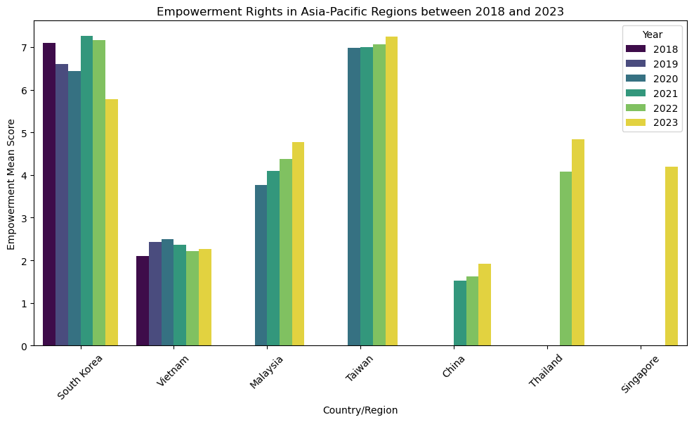

```python
plt.figure(figsize=(12, 6))
sns.barplot(data=merged_df, x='country', y='empower_mean', hue='year', palette='viridis')
plt.title('Empowerment Rights in Asia-Pacific Regions between 2018 and 2023')
plt.ylabel('Empowerment Mean Score')
plt.xlabel('Country/Region')
plt.xticks(rotation=45)
plt.legend(title='Year')
plt.show()
```

5. Observation

The bar chart compares the empowerment scores of Asia-Pacific regions between 2018 and 2023. Taiwan and South Korea rank the highest in empowerment scores among the regions, having average empowerment scores around 7 and 6.5 respectively. Malaysia follow, with an improving empowerment scores from 4 to 5 overtime. Vietnam and China exhibit significantly lower empowerment scores (around 2). Interestingly, while both Vietnam and China are communist countries, Taiwan and South Korean are capitalist regions. This difference in political and economic systems may be a potential factor impacting people's empowerment rights. The data is missing for Thailand and Singapore from 2018 to 2021, posing a difficulty in analyzing their long term trend. However, both countries tend to have similar scores as Malasysia (arounf 4.5), suggesting a similarity shared between capitalist countries in Southeast Asia. Due to the disparity in empowerment scores between capitalist countries/regions and communist countries, further explorations into the impact of governance systems on empowerment scores may provide meaningful insights.

6. Scatter Plot -- Empowerment vs. Education Rights at Risk in Asia-Pacific Regions

```python
scatter_data = merged_df.groupby('country').agg({
    'empower_mean': 'mean',
    'educ_atrisk_prop10': 'mean'
}).reset_index()

# Create the scatter plot using the 'hvplot.scatter' function
scatter = scatter_data.hvplot.scatter(
    x='empower_mean',
    y='educ_atrisk_prop10',
    by='country',
    marker='o',
    c='empower_mean',  # Color points based on 'empower_mean'
    cmap='viridis',  # Apply 'viridis' colormap
    label='country',
    ylabel='Average Proportion of Women/Girls at Risks of Education',
    xlabel='Empowerment Mean'
)

# Customize the plot options
final_plot = scatter.opts(
    title="Interactive Scatter Plot: Average Proportion of Women/Girls' at Risks of Education vs. \n Empowerment Mean between Asia-Pacific Countries",
    legend_position='right',
    width=800,
    height=600
)

# Display the final plot
final_plot
```

[output not shown]

7. Observation

**Insight 3** :

In Asia-pacific regions, capitalist countries/regions generally have higher empowerment rights than communist countries, therefore, political and economic systems may be a potential factor impacting people's empowerment rights. Moreover, a negative correlation is observed between empowerment score and women/girls' risks in education. A higher empowerment score is related to lower risks of women/girls in education. In countries with weaker empowerment rights, women or girls are more likely to experience systemic barriers such as gender inequality or lack of resources, exposing them to higher risks at education. Combining with previous observation that capitalist regions generally have higher empowerment rights, this observation may be shaped by socio-economic and political dynamics in different countries.